# Experimental Design: Introduction

## Subjectivity in data analysis

> “None of this should be understood to mean that any statistical analysis is not inherently subjective, because of course it is–lots of little subjective decisions are involved in all parts of science. It’s just that priors and Bayesian data analysis are no more inherently subjective than are likelihoods and the repeat sampling assumptions required for significance testing. Anyone who has visited a statistics help desk at a university has probably experienced this subjectivity–statisticians do not in general exactly agree on how to analyze anything but the simplest of problems.” (McElreath 2015)

## Why you should care about experimental design

1. Ethics
2. Time
3. Money

*More critical issues in the life sciences:*

1. Random variation
2. Confounding factors

## Defining testable hypotheses

*More important*:

- Defining useful models

**What biological processes could have produced the pattern I am observing?**

- Although your analyses assume the opposite

## Planning

- What do I want to learn?
- What data will I collect?
- Do I have sufficient experimental power?
- How will I analyze the data?
  - What questions can and cannot be answered by my dataset? Consider all the possibilities.

What other data can I collect at the same time that might be useful at some unknown time in the future?

## Randomization and confounding factors

Independence is a critical assumption in (nearly) all your analyses

- Non-random sampling precludes independence

Can we really expect samples to be completely independent?

- Museum specimens
- Fossil record

## Don’t confound your groups

Reviewer:

> The authors are studying the osteohistological correlates of flight mode, yet the three adequately sampled species are completely confounded with both flight style and wing shape, because flight style and wing shape are uniquely associated with one another. Thus it is impossible to disentangle the role of one from the other.

## Beware of batch effects

“Normalization” methods can correct for batch effects statistically, *unless they are confounded with variables of interest!*

[figure not shown]

## Replication and pseudoreplication

**Replication is needed to estimate variation within a group.**

- Replicates must be independent

Think about:

- Common field environments, shared enclosures
- Observations made in batches (days, months, years)
- Repeated measures of a single individual
- Measurements of genetically related units or related species

Some (all?) issues can be addressed statistically.

## Recognize limitations: what question can I really answer?

- Leaf area at one high rainfall and one low rainfall site (10 plots per site)

[figure not shown]

## Recognize limitations: what question can I really answer?

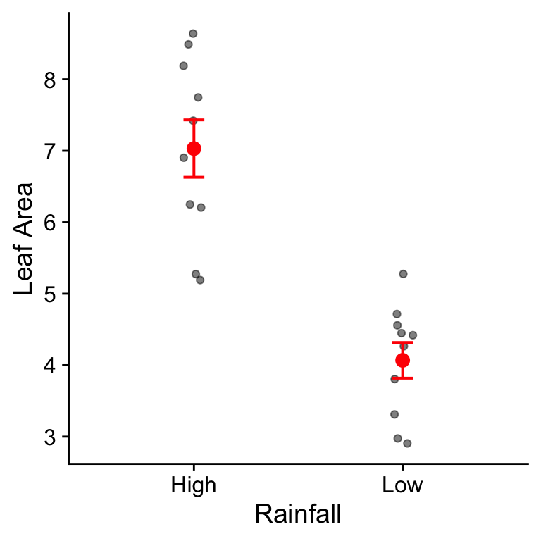

What else might differ between these two individual sites besides rainfall?

## Recognize limitations: what question can I really answer?

- Any two groups are expected to differ for any number of reasons.
  - Replication within these groups will just reveal this difference, not show causality
- You need replication at the level of your variable of interest

## Recognize limitations: what question can I really answer?

Marmots across altitudes & temperatures

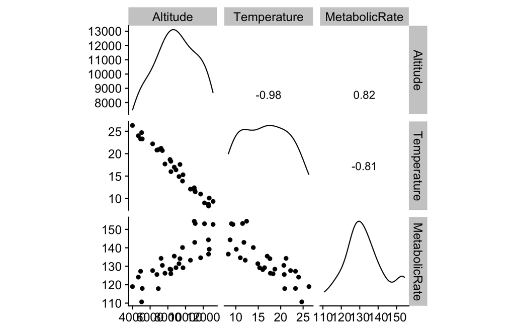

## References

McElreath, R. 2015. *Statistical Rethinking: A Bayesian Course with Examples in R and Stan*. Chapman; Hall/CRC, Boca Raton, FL.